# Assumptions of the t-test

2025

## Assumptions: single-sample t-test

- **Independence**: The observations are independent of each other. This means that one participant’s score does not influence another’s.
- **Normality**: The population from which the sample is drawn is normally distributed. This assumption becomes less critical with larger sample sizes due to the Central Limit Theorem.
- **Scale of measurement**: The dependent variable is measured on a continuous (interval or ratio) scale.

## Independence assumption

- This assumption is **mostly justified by study design**.
- Each observation should be unrelated to others.
- Typical signs of potential dependence:
  - Repeated measures (unless accounted for)
  - Time-ordered data (e.g., learning trials)
  - Clustered data (e.g., students within a class)
- Not directly testable from data in most simple designs.

## Normality assumption

- Can be **inspected visually** or **tested statistically**.
- **Visual checks**:
  - Histogram: should look roughly bell-shaped
  - Boxplot: should be symmetric with no extreme outliers
  - Q-Q plot: points fall on a straight diagonal line (I haven’t shown this one)
- **Statistical tests**:
  - Shapiro-Wilk test (most common)
  - Anderson-Darling or Kolmogorov-Smirnov etc.

## Normality by visual inspection: Example 1

- Participants viewed a high-contrast checkerboard pattern in the left visual field while maintaining central fixation.
- Functional MRI data were collected in a block design, and the percent signal change was extracted from a predefined ROI in primary visual cortex (V1).
- We examine whether the distribution of BOLD signal changes across participants appears normally distributed.

## Normality by visual inspection: Example 1

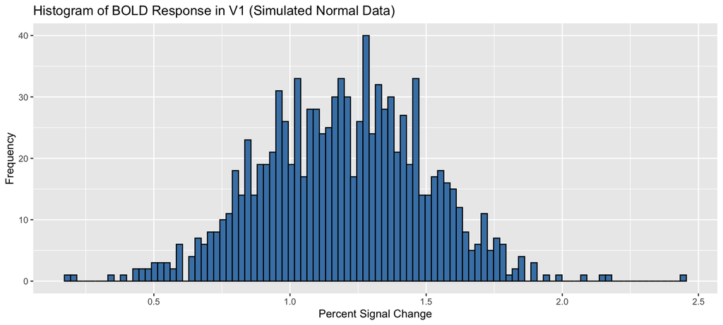

## Normality by visual inspection: Example 2

- Participants completed a perceptual decision-making task in which they had to judge the direction of motion of a cloud of dots.
- We measure reaction times in a perceptual decision task.

## Normality by visual inspection: Example 2

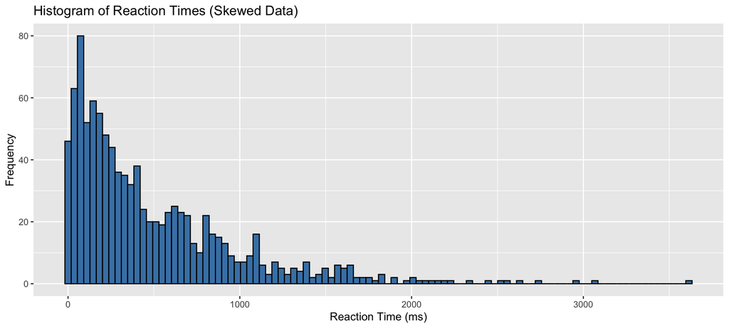

## Weakness of visual inspection

- Visual inspection is subjective
- Small samples sizes are hard to assess
- So formal tests must be better, right?

## Shapiro-Wilk test

- The **Shapiro-Wilk test** is a formal statistical test for normality.

## Generic NHST recipe reminder

1. Specify the null and alternative hypotheses (\(H_0\) and \(H_1\)) in terms of a population parameter \(\theta\).
2. Specify the type I error rate – denoted by the symbol \(\alpha\) – you are willing to tolerate.
3. Specify the sample statistic \(\widehat{\theta}\) that you will use to estimate the population parameter \(\theta\) in step 1 and state how it is distributed under the assumption that \(H_0\) is true.
4. Obtain a random sample and use it to compute the sample statistic from step 3. Call this value \(\widehat{\theta}_{\text{obs}}\).
5. If \(\widehat{\theta}_{\text{obs}}\) or a **more extreme outcome** is very unlikely to occur under the assumption that \(H_0\) is true, then reject \(H_0\). Otherwise, do not reject \(H_0\).

## Shapiro-Wilk test (steps 1 and 2)

- **Specify hypotheses**

\[ \begin{align*} &H_0: \text{Data are normally distributed} \\ &H_1: \text{Data are not normally distributed} \end{align*} \]

- **Choose a significance level**
  - Typically \(\alpha = 0.05\)

## Shapiro-Wilk test (step 3)

-**Choose a test statistic**

\[ W = \frac{\left( \sum_{i=1}^{n} a_i x_{(i)} \right)^2}{\sum_{i=1}^{n} (x_i - \bar{x})^2} \]

- The denominator reflects the total variance in your sample. Dividing by this makes \(W\) scale-invariant.
- The weights \(a_i\) are chosen to reflect the positions you’d expect for the \(i\)th smallest, 2nd smallest, etc., values if you sampled from a normal distribution.
- This makes the numerator reflects how well the sorted values in your sample match the pattern you’d expect if the data came from a normal distribution.
- If your sorted data follow that normal pattern, \(W \approx 1\); Else \(W\) drops toward 0.
- The sampling distribution of \(W\) under the null is not standard like the normal or \(t\). It is estimated for each sample size by repeatedly simulating samples from a normal distribution and calculating \(W\).

## Example in R:

```r
# Simulat RT data (positively skewed)
rt_data <- rexp(100, rate = 1/500)
shapiro.test(rt_data)
```

```
##
##  Shapiro-Wilk normality test
##
## data:  rt_data
## W = 0.86412, p-value = 4.09e-08
```

- If \(p < \alpha\), reject \(H_0\) and conclude that the data are not normally distributed.

## Low power in small samples: SW worse than many NHSTs

- All NHSTs have reduced power with small \(n\)), but SW is especially vulnerable because it tests **a complex composite hypothesis** based on the entire **shape** of the distribution.
- The null hypothesis in SW is broad and hard to falsify: E.g., *data come from some normal distribution* vs *mean equals 0*.
- Small samples have **noisy order statistics**, and since SW relies on the *ordering* and *spacing* of values, this introduces more variability and weakens the signal.

## Oversensitivity in large samples: SW worse than many NHSTs

- Most NHSTs become more sensitive with increasing \(n\), but SW is unusually sensitive because:
- It uses **all** the data (not just a central tendency).
- It looks for **any deviation from normality** e.g. skew, kurtosis, slight multi-modality, etc.
- But the SW test becomes more confident that your data aren’t **perfectly** normal,even if those deviations are unlikely to have a noticable influence on downstream analyses like t-tests or ANOVAs.

## t-test is robust to violations of normality

- Because of the **CLT** large samples (e.g., \(n \geq 30\)) lead to sampling distributions for the sample mean and corresponding \(t\) that are approximately normal, even if the population is not.
- If the population is **skewed** or has **outliers**, the CLT convergence to normality is slower.
- This means **larger samples** are required for the *t*-test to remain valid.

## What does it mean to be robust?

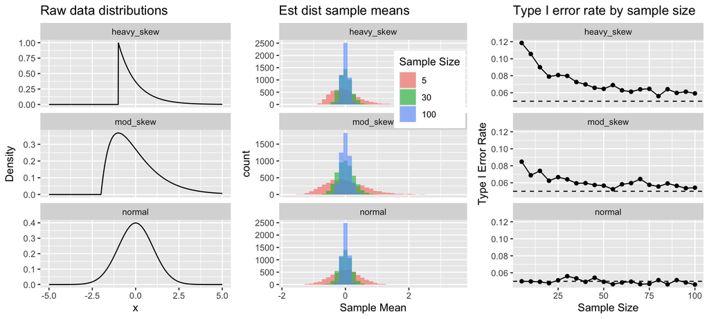

## Key takeaways

- The *t*-test assumes independence, normality, and continuous measurement.
- Independence is handled via good design.
- Normality can be inspected visually and tested but neither method is perfect.
- CLT causes robustness of the \(t\)-test but with heavy skew or large outliers, you may need much larger samples.

## Alternatives when assumptions are violated

- Use nonparametric tests (e.g., Wilcoxon signed-rank test)
- Use robust methods (e.g., Bootstrapping)
- Transform the data (e.g., log transformation)
- **All beyond the scope of this course!**